# ProyectoTD2026

Tratamiento de los Datos. Grado en Ciencia de Datos- UV

GrupoH

2026-05-08

**Palabras clave:** Análisis, Moodle, R, limpieza de datos, Tratamiento de Datos.

# Introduccion

## Contexto del proyecto

La digitalización de la enseñanza superior ha transformado las plataformas de aprendizaje virtual, como Moodle, en fuentes masivas de datos. Cada interacción de un estudiante genera un registro que, analizado correctamente, puede revelar patrones de comportamiento invisibles a simple vista.

Este proyecto surge de la necesidad de aplicar técnicas de Ciencia de Datos sobre el conjunto de registros de la asignatura “Tratamiento de Datos” de la Universitat de València. El propósito no es solo limpiar y organizar la información, sino realizar un Análisis Exploratorio de Datos (AED) profundo que nos permita comprender la dinámica del curso durante el segundo cuatrimestre.

## Preguntas de investigación

Para alcanzar el objetivo establecido, el trabajo se estructura en torno a la resolución de las siguientes preguntas de investigación:

- ¿En qué días de la semana y franjas horarias se concentran los mayores picos de actividad de los alumnos?
- ¿Es posible identificar y agrupar a los alumnos en distintos “perfiles de estudiante” (ej. constantes, de última hora, inactivos) según sus patrones de uso del Aula Virtual?
- ¿Con cuánta antelación entregan el Miniproyecto los alumnos?
- ¿Existe una diferencia significativa en la actividad de los alumnos entre los días laborables y los fines de semana o festivos?
- ¿Qué porcentaje de la actividad se realiza en la ETSE y qué porcentaje se realiza fuera de esta?
- ¿Hay más actividad provocada por las tareas o se produce más para revisar los apuntes de cada tema?

# Metodología y Preparación de Datos

La fase de preparación de datos es la etapa crítica de este proyecto, para garantizar la calidad, consistencia y fiabilidad de los resultados. En esta sección se detalla el proceso de ingesta, limpieza y transformación del conjunto de datos original (`logs_moodle_anon.csv`), adaptándolo para el Análisis Exploratorio de Datos.

Para llevar a cabo este procesamiento, se ha utilizado el entorno de programación R, empleando la colección de paquetes `tidyverse` para la manipulación eficiente de *dataframes* y la librería `lubridate` para el tratamiento avanzado de series temporales.

El flujo de trabajo aplicado consta de las siguientes fases metodológicas:

## Importación y estandarización

En primer lugar, se procede a la carga del archivo original. Las bases de datos provenientes de sistemas como Moodle suelen contener nombres de columnas con espacios y caracteres especiales. Para facilitar el manejo programático y mantener un código limpio, se han renombrado estas variables bajo un estándar consistente (por ejemplo, transformando “Nombre completo del usuario” a `usuario` y “Contexto del evento” a `contexto`).

## Gestión temporal e Ingeniería de variables

Dado que gran parte de nuestras preguntas de investigación tienen un carácter cronológico, la variable original de tiempo se ha convertido al formato estándar de fecha y hora (`POSIXct`) mediante la función `dmy_hms()`. A partir de esta marca temporal, se han extraído e ingeniado nuevas características (*feature engineering*) que serán fundamentales para el análisis: la fecha exacta (`fecha`), la hora del día (`hora`), el día de la semana (`dia_semana`) y el mes (`mes`).

## Limpieza, tipado y filtrado

Para delimitar el alcance del estudio al periodo lectivo correspondiente, se ha aplicado un filtro para conservar exclusivamente los registros del cuatrimestre activo (del 1 de enero al 31 de julio de 2025).

Además, se ha realizado una conversión de tipos de datos (*Type casting*), transformando las variables de naturaleza categórica a formato *factor*. Esta operación no solo optimiza el uso de la memoria, sino que es un requisito indispensable para la correcta generación de gráficos y la aplicación de métodos estadísticos. Finalmente, para asegurar la integridad de la información, se han eliminado los posibles registros duplicados del sistema, obteniendo así nuestro conjunto de datos final y limpio.

```
Rows: 107,105
Columns: 13
$ fecha_hora       <dttm> 2025-07-17 16:19:19, 2025-07-17 16:19:09, …
$ usuario          <fct> U0027, U0027, U0022, U0022, U0022, U0110, U…
$ usuario_afectado <fct> NA, NA, NA, U0022, NA, NA, NA, NA, NA, NA, …
$ contexto         <fct> Curso: 2024-25 Tractament de les dades Gr.A…
$ componente       <fct> Sistema, Foro, Sistema, Usuario, Sistema, S…
$ evento           <fct> Curso visto, Tema visto, Curso visto, Infor…
$ descripcion      <chr> "The user with id '303510' viewed the cours…
$ origen           <fct> web, web, web, web, web, web, web, web, web…
$ ip               <chr> "2a09:bac2:3136:191:0:0:28:111", "2a09:bac2…
$ fecha            <date> 2025-07-17, 2025-07-17, 2025-07-16, 2025-0…
$ hora             <int> 16, 16, 19, 19, 19, 11, 23, 21, 21, 21, 17,…
$ dia_semana       <ord> jueves, jueves, miércoles, miércoles, miérc…
$ mes              <ord> jul, jul, jul, jul, jul, jul, jul, jul, jul…
```

# Análisis y visualización de datos.

El Análisis Exploratorio de Datos constituye la fase central de nuestro estudio. En esta etapa, aplicamos técnicas estadísticas y de visualización para descubrir patrones, comprender la distribución de la actividad en el Aula Virtual y asentar las bases antes de responder a las preguntas de investigación.

## Análisis Estructural y Diccionario de Datos

Tras ejecutar el proceso de limpieza y la creación de nuevas variables temporales (*Feature Engineering*), el conjunto de datos definitivo (`logs`) se compone de **107.105 observaciones** y **13 variables**. Este volumen de registros limpios representa el núcleo de nuestro análisis.

A continuación, en la Tabla @ref(tab:resumen-dataset) se exponen las métricas generales que dimensionan el ecosistema de la asignatura, mostrando la cantidad de alumnos implicados y la diversidad de acciones que pueden realizar.

Resumen estructural del conjunto de datos.

| Métrica | Valor |
| --- | --- |
| Total de registros (limpios) | 107105 |
| Usuarios únicos | 83 |
| Tipos de eventos distintos | 106 |
| Componentes distintos | 25 |

Para garantizar la reproducibilidad y la correcta interpretación de los análisis posteriores, es indispensable documentar el estado final de las características del dataframe. El Diccionario de Datos resultante, donde se especifican los tipos (como Factor o POSIXct), se presenta en la Tabla @ref(tab:diccionario-datos).

Diccionario de datos final tras el proceso de ingeniería de variables.

| Variable | Tipo | Descripción |
| --- | --- | --- |
| fecha_hora | POSIXct (datetime) | Marca de tiempo completa (fecha y hora). |
| usuario | Factor | Identificador único del usuario (anonimizado). |
| usuario_afectado | Factor | Usuario sobre el que recae la acción (si aplica). |
| contexto | Factor | Entorno o curso donde ocurre el evento. |
| componente | Factor | Módulo de Moodle (Tarea, Foro, Sistema, etc.). |
| evento | Factor | Acción específica realizada por el usuario. |
| descripcion | Character | Descripción detallada de la interacción. |
| origen | Factor | Plataforma de acceso (web o móvil). |
| ip | Character | Dirección de red del dispositivo (IPv4/IPv6). |
| fecha | Date | Fecha del evento (YYYY-MM-DD). |
| hora | Integer | Hora del día en formato 24h (0-23). |
| dia_semana | Ordered Factor | Día de la semana (Lunes-Domingo). |
| mes | Ordered Factor | Mes del año (Enero-Diciembre). |

## Exploración Univariante: Distribución de la actividad general

Una vez validada la integridad y estructura de la información, procedemos a examinar cómo se distribuyen de forma general estos registros. Comprender en qué momentos del día interactúan los alumnos con la plataforma es vital para establecer el ritmo base de la asignatura.

Como ejemplo principal de esta exploración univariante, la Figura @ref(fig:distribucion-horas) ilustra la frecuencia de los accesos e interacciones a lo largo de las distintas horas del día. Esta visualización nos permite identificar de un vistazo las franjas de mayor rendimiento y los periodos de inactividad nocturna.

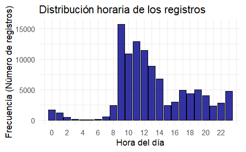

## Detección y análisis de valores atípicos (Outliers)

En el contexto de la Analítica del Aprendizaje, el volumen de actividad de un estudiante en el Aula Virtual rara vez sigue una distribución normal perfecta, ya que suele presentar una fuerte asimetría positiva. Por tanto, es fundamental identificar si existen usuarios con un comportamiento anómalo (*outliers*), ya sea por un exceso de interacciones (“hiperactivos”) o por un déficit preocupante (“inactivos”).

Para llevar a cabo esta detección de forma robusta, hemos aplicado el método no paramétrico del **Rango Intercuartílico (IQR)** sobre el volumen total de clics por usuario. Este método define como atípico cualquier valor que se aleje 1.5 veces el tamaño del IQR por encima del tercer cuartil ($Q_3$) o por debajo del primer cuartil ($Q_1$).

El siguiente bloque de código calcula estos límites estadísticos, aísla a los estudiantes con comportamiento extremo en la Tabla @ref(tab:analisis-outliers) y proyecta visualmente la distribución de toda la clase en la Figura @ref(fig:analisis-outliers).

Listado de estudiantes con comportamiento atípico (Outliers).

| usuario | total_interacciones | perfil_actividad |
| --- | --- | --- |
| U0072 | 12688 | Atípico Alto (Hiperactivo) |
| U0001 | 6916 | Atípico Alto (Hiperactivo) |
| U0095 | 2795 | Atípico Alto (Hiperactivo) |
| U0012 | 2651 | Atípico Alto (Hiperactivo) |
| U0006 | 2583 | Atípico Alto (Hiperactivo) |
| U0045 | 44 | Atípico Bajo (Inactivo) |
| U0053 | 40 | Atípico Bajo (Inactivo) |
| U0101 | 16 | Atípico Bajo (Inactivo) |
| U0057 | 10 | Atípico Bajo (Inactivo) |
| U0002 | 8 | Atípico Bajo (Inactivo) |
| U0010 | 3 | Atípico Bajo (Inactivo) |

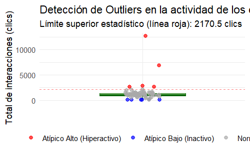

# Resultados: Respuesta a las Preguntas de Investigación

```r
# 1. Filtramos solo los eventos de entrega de Tareas
# Buscamos la acción donde el alumno realmente envía el trabajo
entregas_reales <- logs %>%
  filter(
    componente == "Tarea",
    str_detect(evento, "entrega|Submission") # Filtra eventos que contengan la palabra "entrega" o "Submission"
  )

# 2. Inyectamos la fecha/hora exacta de cierre del Miniproyecto
fecha_cierre_miniproyecto <- ymd_hms("2025-05-13 23:55:00")

# 3. Calculamos la diferencia en horas
analisis_antelacion <- entregas_reales %>%
  # Nos quedamos con las entregas de mayo (para aislar las del Miniproyecto)
  filter(fecha >= as.Date("2025-05-01") & fecha_hora <= fecha_cierre_miniproyecto) %>%
  # Nos quedamos con la última entrega de cada usuario por si la modificaron
  group_by(usuario) %>%
  filter(fecha_hora == max(fecha_hora)) %>%
  ungroup() %>%
  mutate(
    # Calculamos cuántas horas faltaban para el cierre
    horas_antelacion = as.numeric(difftime(fecha_cierre_miniproyecto, fecha_hora, units = "hours")),
    # Clasificamos al alumno
    perfil_entrega = case_when(
      horas_antelacion > 48 ~ "Con mucha antelación (>2 días)",
      horas_antelacion > 24 & horas_antelacion <= 48 ~ "El día de antes",
      horas_antelacion > 6 & horas_antelacion <= 24 ~ "El mismo día",
      horas_antelacion <= 6 ~ "Último minuto (<6 horas)"
    )
  )

# 4. Tabla resumen de perfiles
resumen_antelacion <- analisis_antelacion %>%
  group_by(perfil_entrega) %>%
  summarise(numero_alumnos = n()) %>%
  mutate(porcentaje = round((numero_alumnos / sum(numero_alumnos)) * 100, 1)) %>%
  arrange(desc(porcentaje))

knitr::kable(resumen_antelacion, caption = "Clasificación de los alumnos según la antelación de entrega (Miniproyecto).")
```

Clasificación de los alumnos según la antelación de entrega (Miniproyecto).

| perfil_entrega | numero_alumnos | porcentaje |
| --- | --- | --- |
| Último minuto (<6 horas) | 41 | 46.1 |
| Con mucha antelación (>2 días) | 18 | 20.2 |
| El día de antes | 16 | 18.0 |
| El mismo día | 14 | 15.7 |

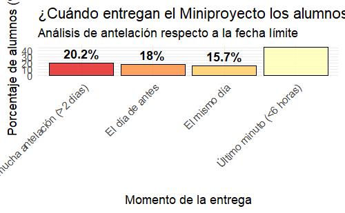

```r
# 5. Gráfico de barras
# Reordenamos los factores para que el gráfico tenga un orden lógico temporal
resumen_antelacion$perfil_entrega <- factor(resumen_antelacion$perfil_entrega,
                                            levels = c("Con mucha antelación (>2 días)",
                                                       "El día de antes",
                                                       "El mismo día",
                                                       "Último minuto (<6 horas)"))

ggplot(resumen_antelacion, aes(x = perfil_entrega, y = porcentaje, fill = perfil_entrega)) +
  geom_col(color = "black", alpha = 0.8) +
  geom_text(aes(label = paste0(porcentaje, "%")), vjust = -0.5, fontface = "bold") +
  scale_fill_brewer(palette = "YlOrRd", direction = -1) + # Paleta que va de suave a rojo urgencia
  labs(title = "¿Cuándo entregan el Miniproyecto los alumnos?",
       subtitle = "Análisis de antelación respecto a la fecha límite",
       x = "Momento de la entrega",
       y = "Porcentaje de alumnos (%)") +
  theme_minimal() +
  theme(legend.position = "none",
        axis.text.x = element_text(angle = 45, hjust = 1))
```

- ¿Existe una diferencia significativa en la actividad de los alumnos entre los días laborables y los fines de semana o festivos?

```r
# PREGUNTA: ¿Hay diferencias entre días laborables, fines de semana y festivos?

# 1. INYECCIÓN DE CONTEXTO: Definimos los festivos oficiales (Calendario UV 2025)
# Ajusta estas fechas según el calendario académico real de tu curso
festivos_uv <- as.Date(c(
  "2025-01-01", "2025-01-06", "2025-01-22", # Año Nuevo, Reyes, San Vicente Mártir
  "2025-03-17", "2025-03-18", "2025-03-19", # Semana de Fallas (días sin clase)
  "2025-04-17", "2025-04-18", "2025-04-21", "2025-04-28", # Jueves Santo a San Vicente Ferrer
  "2025-05-01",                             # Día del Trabajador
  "2025-06-24"                              # San Juan
))

# 2. Agrupamos la actividad por día y clasificamos
actividad_calendario <- logs %>%
  # Agrupamos todo por día para contar cuántos clics hubo
  group_by(fecha) %>%
  summarise(interacciones = n()) %>%
  mutate(
    # Usamos week_start = 1 para que Lunes sea 1 y Domingo 7
    dia_semana_num = wday(fecha, week_start = 1),
    tipo_dia = case_when(
      fecha %in% festivos_uv ~ "Festivo (Sin clase)",
      dia_semana_num %in% c(6, 7) ~ "Fin de semana",
      TRUE ~ "Laborable"
    )
  )

# 3. TABLA: Comparamos las medias y medianas
resumen_calendario <- actividad_calendario %>%
  group_by(tipo_dia) %>%
  summarise(
    dias_totales = n(),
    media_diaria = round(mean(interacciones), 1),
    mediana_diaria = median(interacciones) # Usamos mediana para que los picos no distorsionen tanto
  ) %>%
  arrange(desc(media_diaria))

knitr::kable(resumen_calendario, caption = "Actividad media y mediana según el calendario académico.")
```

Actividad media y mediana según el calendario académico.

| tipo_dia | dias_totales | media_diaria | mediana_diaria |
| --- | --- | --- | --- |
| Laborable | 127 | 747.9 | 565 |
| Fin de semana | 52 | 209.2 | 112 |
| Festivo (Sin clase) | 11 | 113.8 | 136 |

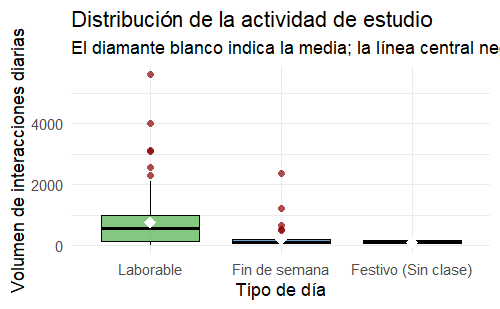

```r
# 4. GRÁFICO: Boxplot para ver la "diferencia significativa" visualmente
# El factor se reordena para que salga en un orden lógico en el gráfico
actividad_calendario$tipo_dia <- factor(actividad_calendario$tipo_dia,
                                        levels = c("Laborable", "Fin de semana", "Festivo (Sin clase)"))

ggplot(actividad_calendario, aes(x = tipo_dia, y = interacciones, fill = tipo_dia)) +
  geom_boxplot(alpha = 0.7, color = "black", outlier.color = "darkred", outlier.shape = 16) +
  # Añadimos la media como un punto blanco extra dentro de la caja
  stat_summary(fun = mean, geom = "point", shape = 18, size = 3, color = "white") +
  scale_fill_manual(values = c("Laborable" = "#4DAF4A",
                               "Fin de semana" = "#377EB8",
                               "Festivo (Sin clase)" = "#E41A1C")) +
  labs(title = "Distribución de la actividad de estudio",
       subtitle = "El diamante blanco indica la media; la línea central negra, la mediana.",
       x = "Tipo de día",
       y = "Volumen de interacciones diarias") +
  theme_minimal() +
  theme(legend.position = "none")
```

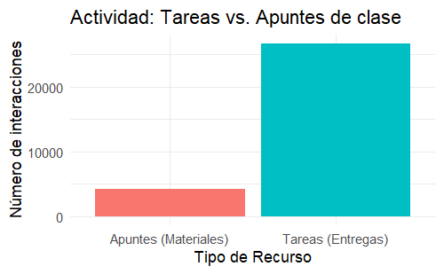

# Discusión de los resultados